# 5500 Project

## Abstract

Using Graphviz, Streamlit, and Python, this project creates a novel interactive visualization tool for linked lists. This application replaces static graphics and theoretical explanations with a dynamic, interactive environment, improving the learning process for students acquiring a foundational understanding of data structures. Linked lists are fundamental computer science structures that control dynamic data allocation, a notion that can be difficult for students to understand from textual explanations alone.

The project allows users to actively alter linked lists in real-time in addition to visualizing them. This is achieved by using a dynamic visualizer. Users may watch and learn how actions like insertion, deletion, sorting, and retrieval impact the behavior and structure of linked lists with the aid of this interactive approach. Every action has a visible reflection, providing instantaneous feedback on the modifications’ impact. Users can append or insert strings and integers, see how nodes reorder during sorting, or see the instantaneous effect of removing a node.

An interactive tool that puts these ideas into practice encourages a more in-depth, hands-on learning approach, which makes it a priceless teaching tool for instructors and students alike. It acts as a link between abstract ideas of data structures and their concrete applications, offering an interactive, educational, and entertaining learning experience. As a result, this visualizer stands out as an essential tool for improving learning since it presents complicated ideas in an understandable way that greatly facilitates understanding and recall of the principles of data structure.

## Introduction

The goal of this project is to use Graphviz, Streamlit, and Python to create an interactive visualization tool for linked lists. In computer science, linked lists are essential data structures that are necessary to comprehend the dynamic storage and management of data. While static visuals and descriptions are the mainstay of traditional teaching methods, this project offers an interactive, real-time visualization of linked list operations that improves learning.

**Technologies Used**

The project’s core language is Python, which also handles Streamlit and Graphviz integration and provides the logic for linked list operations.

Streamlit: Makes it easier to create a web-based interface, allowing for interactive user interaction without requiring advanced web programming knowledge.

Graphviz: This tool creates the linked list’s visual representation, which shows the list’s current state and structure following each action.

## Code

The initial code is stolen from Jeff ((jpowerj) (2023)). Thanks a lot for his contribution!

```python
import streamlit as st
from graphviz import Digraph, nohtml

st.header("LinkedList Visualizer")
st.markdown("Enter a **value** on the left and click **add** to start your LinkedList! Number in the bracket after the value is corresponding index.")

viz_elt = st.empty()

with st.sidebar.form("ll_entry"):
    st.header("Enter a value to add:")
    user_val = st.text_input("Value")
    submitted = st.form_submit_button("Click to add")

#@title define-ll-and-visualizer

### Regular (non-circular) LinkedList definition:

class LinkedList:
  def __init__(self):
    self.root = None

  def append(self, item: object) -> None:
    if self.root is None:
      self.root = LLNode(item)
    else:
      self.root.append(item)

  def insert(self, item: object, index: int) -> None:
      if index == 0:
          new_node = LLNode(item)
          new_node.next = self.root
          self.root = new_node
      else:
          prev = None
          current = self.root
          current_index = 0
          while current_index < index and current is not None:
              prev = current
              current = current.next
              current_index += 1
          if prev is not None:
              new_node = LLNode(item)
              new_node.next = current
              prev.next = new_node

  def delete(self, index: int) -> None:
      if index == 0:
          self.root = self.root.next
      else:
          prev = None
          current = self.root
          current_index = 0
          while current_index < index and current is not None:
              prev = current
              current = current.next
              current_index += 1
          if prev is not None:
              prev.next = current.next

  def retrieve(self, index: int) -> object:
      current = self.root
      current_index = 0
      while current_index < index and current is not None:
          current = current.next
          current_index += 1
      if current is not None:
          return current.content
  def sort(self):
      if self.root is None or self.root.next is None:
          return
      # Bubble sort
      changed = True
      while changed:
          current = self.root
          prev = None
          changed = False
          while current is not None and current.next is not None:
              if current.content > current.next.content:
                  changed = True
                  if prev is None:
                      tmp = current.next
                      current.next = tmp.next
                      tmp.next = current
                      self.root = tmp
                      prev = tmp
                  else:
                      tmp = current.next
                      current.next = tmp.next
                      tmp.next = current
                      prev.next = tmp
                      prev = tmp
              else:
                  prev = current
                  current = current.next

  def __len__(self) -> int:
    if self.root is None:
      return 0
    else:
      return len(self.root)

  def to_string(self) -> str:
    if self.root is None:
      return 'LinkedList[]'
    else:
      return f'LinkedList[{self.root.to_string()}]'

  def __str__(self) -> str:
    return self.to_string()

  def __repr__(self) -> str:
    return self.to_string()

class LLNode:
  def __init__(self, item: object):
    self.content = item
    self.next = None

  def append(self, item: object) -> None:
    if self.next is None:
      self.next = LLNode(item)
    else:
      self.next.append(item)

  def __len__(self) -> int:
    if self.next is None:
      return 1
    else:
      return 1 + len(self.next)

  def to_string(self) -> str:
    content_str = f'LLNode[{self.content}] '
    if self.next is None:
      return content_str
    else:
      next_str = self.next.to_string()
      return f'{content_str}{next_str}'

  def __str__(self) -> str:
    return self.to_string()

  def __repr__(self) -> str:
    return self.to_string()

# Helper function for visualizing both regular and circular linked lists:

def visualize_ll(ll):
    dot = Digraph(
        graph_attr={'rankdir': 'LR'},
        node_attr={'shape': 'record', 'height': '.1'}
    )
    node_pointer = ll.root
    index = 0
    prev_node_name = None

    while node_pointer is not None:
        node_label = f'{node_pointer.content} ({index})'  # Include index in the label
        node_name = f'node{index}'  # Create a unique node name using the index

        # Create node with label
        dot.node(name=node_name, label=nohtml('<f0> |' + node_label + '|<f1>'))

        # Connect the current node with the previous node if not the first node
        if prev_node_name is not None:
            dot.edge(f'{prev_node_name}:f1', f'{node_name}:f0')

        # Update previous node name and move to the next node
        prev_node_name = node_name
        node_pointer = node_pointer.next
        index += 1

    viz_elt.graphviz_chart(dot)


if 'palette' not in st.session_state:
    st.session_state['palette'] = LinkedList()

visualize_ll(st.session_state['palette'])

if submitted:
    if user_val == "":
      st.sidebar.error("Please enter a value")
    else:
      st.session_state['palette'].append(user_val)
      st.toast(f"Added {user_val}")

with st.sidebar:
    st.header("Operations")
    # inserting items
    add_val = st.text_input("Value to insert")
    add_index = st.number_input("Index to insert at", min_value=0, format="%d")
    add_btn = st.button("insert")

    # Deleting items
    del_index = st.number_input("Index to delete at", min_value=0, format="%d")
    del_btn = st.button("Delete")

    # Retrieving items
    get_index = st.number_input("Index to get value from", min_value=0, format="%d")
    get_btn = st.button("Get Value")

    # Sorting
    sort_btn = st.button("Sort List From Low to High")

if add_btn:
    if add_index is None or add_index == 0:
        st.session_state['palette'].append(add_val)
    else:
        st.session_state['palette'].insert(add_val, add_index)
    st.toast(f"Added {add_val} at index {add_index}")
    visualize_ll(st.session_state['palette'])

if del_btn:
    st.session_state['palette'].delete(del_index)
    st.toast(f"Deleted item at index {del_index}")
    visualize_ll(st.session_state['palette'])

if get_btn:
    value = st.session_state['palette'].retrieve(get_index)
    if value is not None:
        st.sidebar.write(f"Value at index {get_index}: {value}")
    else:
        st.sidebar.error("No value found at that index.")
    visualize_ll(st.session_state['palette'])

if sort_btn:
    st.session_state['palette'].sort()
    st.toast("List sorted")
    visualize_ll(st.session_state['palette'])


visualize_ll(st.session_state['palette'])
```

## Comment on code

**LinkedList Class:** Manages the overall operations of the linked list. It supports various methods to manipulate the list data: - append(item): Appends a new entry to the list’s end. The new item becomes the root if the list is empty. - insert(item, index): Inserts an item at a specified index. This method handles edge cases such as inserting at the beginning and middle of the list. - delete(index): To preserve list integrity, removes an item from a given index while modifying pointers. - retrieve(index): Provides simple access to any node by returning the value of the node at the given index. - sort(): Arranges the components of the linked list in ascending order by applying a bubble sort. This sorting technique isn’t the most effective for huge datasets, but it was chosen for its ease of use and instructional clarity.

**LLNode Class:** Represents individual elements (nodes) in the linked list. Each node contains: - content: The data stored in the node. - next: a pointer to the node that comes after it in the list, or None if it is the final node.

## Visual Tool (Streamlit App)

[Portal Here!](https://nrkl5qyzp3yln2bcjosfh3.streamlit.app/), and you can find [code](https://github.com/1152586743/5500) in my github (Yian Hu (2023))

**Append Operation:** Users can add new elements to the linked list by specifying values in the input field. This action appends elements to the end of the list, as demonstrated in the initial setup where values 10, 25, and 3 were added sequentially, resulting in a list with respective indices 0, 1, and 2 (See Figure 1).

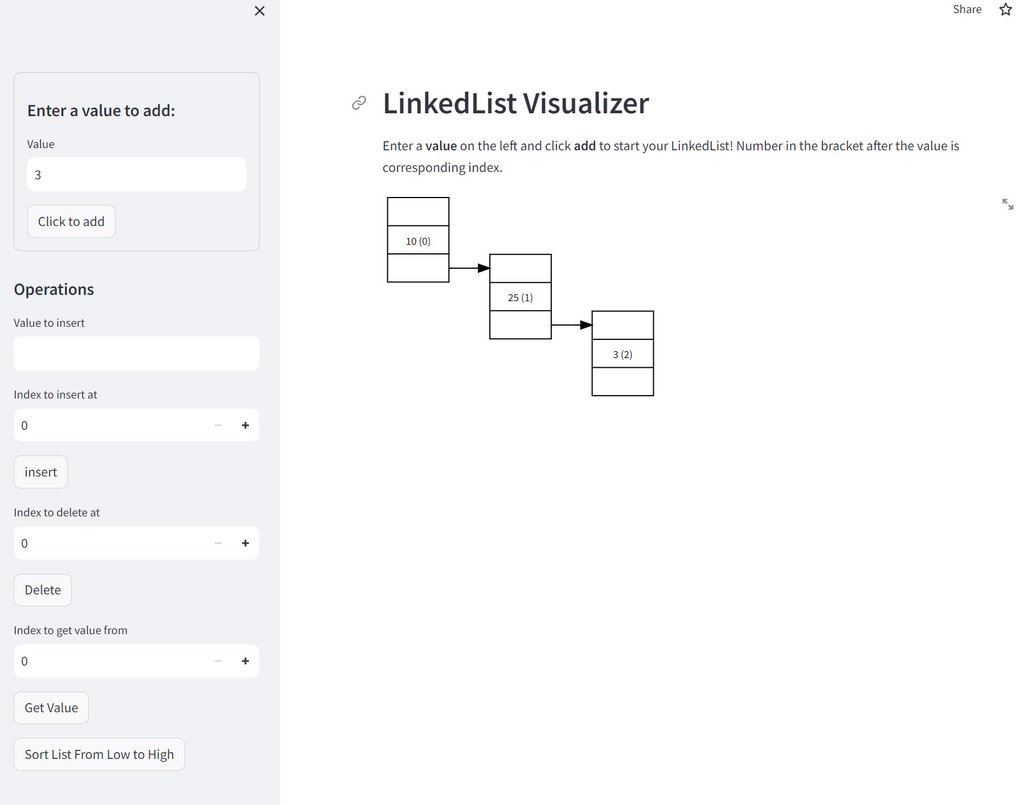

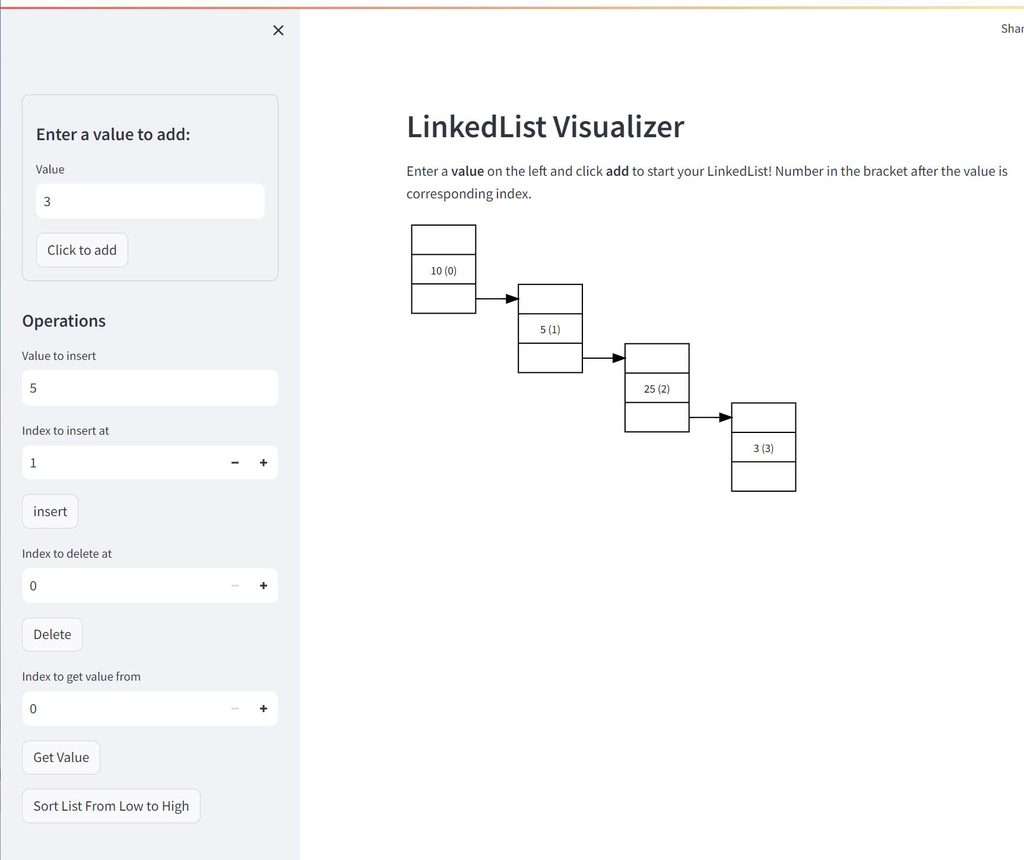

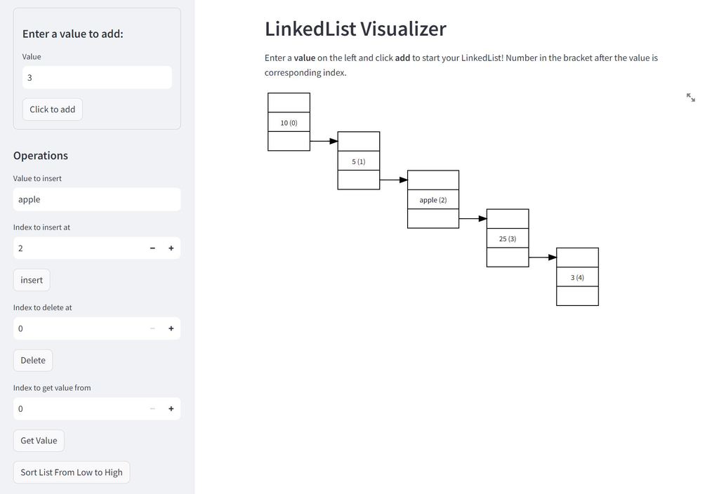

**Delete Operation:** Users can remove elements from the list by specifying an index. This operation not only removes the element but also updates the indices of subsequent elements to fill the gap. An example is shown where “apple” is deleted from the list, effectively updating the list structure and indices (See Figure 4).

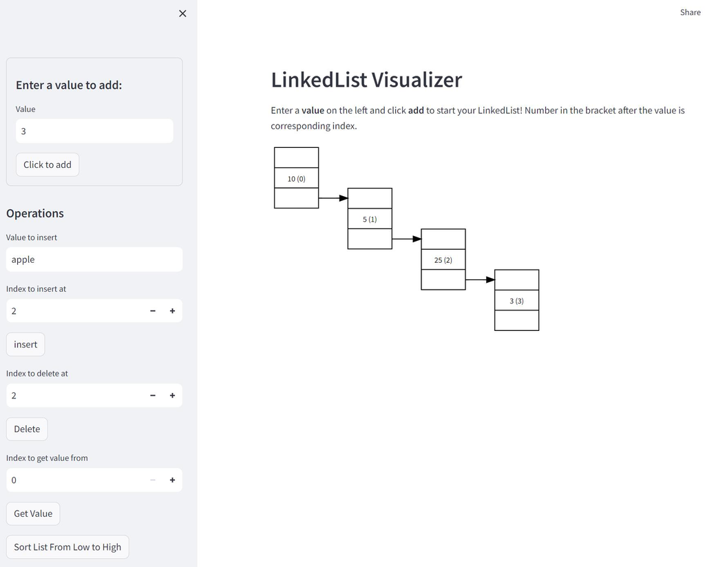

**Retrieve Operation:** This tool also provides functionality to retrieve the value at a specific index, which helps in verifying the current state of the list. For example, retrieving the value at index 1 post-insertion confirms the correct placement of elements (See Figure 5).

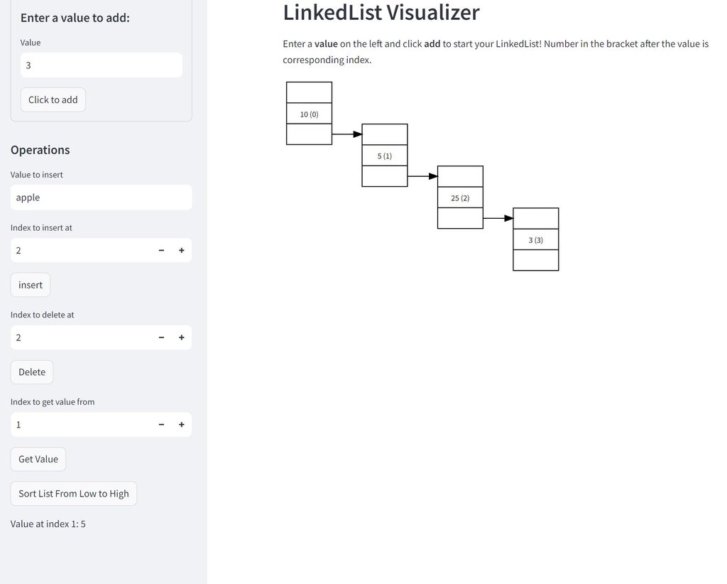

[figure not shown]

## References

(jpowerj), J. Power. 2023. “Streamlit LinkedList Visualizer.” *GitHub Repository*. https://github.com/jpowerj/streamlit-linkedlist; GitHub.

Yian Hu, GitHub user: 2023. “5500.” *GitHub Repository*. https://github.com/1152586743/5500; GitHub.